# TASK5：AI交易引擎：机器学习算法与场景应用

本 notebook 用于完成 TASK5 的文字回答和 Python 实践。任务要求可以使用股票收益分类数据，也可以使用 scikit-learn 自带的乳腺癌二分类数据集。本 notebook 选择 scikit-learn 内置乳腺癌数据集作为样例数据，因为它是标准二分类数据，不需要 Tushare Token，也便于完整展示训练集/测试集划分、模型训练、AUC 计算和 ROC 曲线绘制。

## 一、分类型机器学习算法解释

分类算法用于预测样本属于哪一个类别。在量化交易中，分类模型可以被用来判断“未来收益是否为正”“是否出现买入信号”“股票是否进入高风险状态”等二分类或多分类问题。本任务重点了解逻辑回归、决策树和随机森林三类常见分类算法。

### 1. 逻辑回归 Logistic Regression

逻辑回归虽然名字里有“回归”，但它常用于分类问题。它通过特征变量的线性组合计算一个概率值，再根据概率是否超过阈值判断类别。例如在二分类中，模型可以输出某个样本属于正类的概率。如果概率大于 0.5，就预测为正类；否则预测为负类。

逻辑回归的优点是模型结构简单、训练速度快、结果相对容易解释。每个特征对应一个系数，系数正负可以帮助理解该特征对分类结果的影响方向。缺点是它主要刻画线性关系，如果数据中存在复杂非线性结构，单独使用逻辑回归可能表现有限。

### 2. 决策树 Decision Tree

决策树是一种类似“规则判断”的分类模型。它会根据特征的取值不断进行分裂，例如“某个指标是否大于某个阈值”，最终把样本分到不同类别。决策树的结构类似流程图，因此可解释性较强。

决策树的优点是容易理解，能够处理非线性关系，也不需要对特征做复杂标准化。缺点是单棵树容易过拟合，也就是在训练集上表现很好，但在测试集上泛化能力不足。因此实际使用时常通过限制树深度、设置最小样本数等方式控制复杂度。

### 3. 随机森林 Random Forest

随机森林是一种集成学习模型，它由多棵决策树组成。每棵树使用部分样本和部分特征进行训练，最后通过投票或平均概率得到最终分类结果。

随机森林的优点是比单棵决策树更稳定，抗过拟合能力更强，能够处理非线性关系，并且可以输出特征重要性。缺点是模型比单棵树更复杂，解释性稍弱，训练和预测成本也更高。

在量化交易中，随机森林可以用于综合多个技术指标、财务指标和行情特征，判断未来收益方向或风险状态。

## 二、机器学习模型评价指标解释

分类模型不能只看预测是否“看起来合理”，还需要通过评价指标进行检验。本任务重点解释混淆矩阵、ROC 曲线和 AUC。

### 1. 混淆矩阵 Confusion Matrix

混淆矩阵用于比较模型预测类别和真实类别之间的关系。二分类混淆矩阵通常包含四个部分：

- **TP 真正例**：真实为正类，模型也预测为正类。
- **TN 真负例**：真实为负类，模型也预测为负类。
- **FP 假正例**：真实为负类，但模型预测为正类。
- **FN 假负例**：真实为正类，但模型预测为负类。

混淆矩阵可以帮助观察模型错在哪里。例如在金融场景中，如果把“未来上涨”作为正类，那么假正例可能表示模型误判上涨，导致错误买入；假负例可能表示模型错过上涨机会。

### 2. ROC 曲线 Receiver Operating Characteristic Curve

ROC 曲线用于评价二分类模型在不同分类阈值下的表现。横轴是假正率 FPR，纵轴是真正率 TPR。

- `TPR = TP / (TP + FN)`，表示正类样本中被正确识别出来的比例，也叫召回率。
- `FPR = FP / (FP + TN)`，表示负类样本中被错误预测为正类的比例。

当分类阈值变化时，TPR 和 FPR 会一起变化。ROC 曲线越靠近左上角，说明模型越能在较低误判率下识别更多正类，模型区分能力越强。

### 3. AUC Area Under Curve

AUC 是 ROC 曲线下方的面积，用于衡量模型整体区分正负样本的能力。AUC 的取值通常在 0 到 1 之间：

- AUC = 0.5：模型接近随机猜测。
- AUC 越接近 1：模型区分能力越强。
- AUC 小于 0.5：模型可能方向反了，预测效果比随机还差。

在量化交易中，AUC 可以用来判断模型是否能够有效区分“未来上涨”和“未来下跌”等类别。不过 AUC 高并不等于策略一定赚钱，还需要结合交易成本、仓位管理、回撤和实盘约束进一步评估。

## 三、Python 实践目标

本次 Python 实践完成以下任务：

1. 加载 scikit-learn 内置乳腺癌二分类数据集，应变量为 0 或 1。
2. 将数据划分为训练集和测试集。
3. 构建并训练逻辑回归、决策树、随机森林三个分类模型。
4. 在测试集上评估模型表现，计算准确率、精确率、召回率、F1 值和 AUC。
5. 绘制混淆矩阵和 ROC 曲线。
6. 输出随机森林的特征重要性，帮助理解模型关注的主要特征。

```python
# 安装并导入本作业所需的基础库。
import importlib.util
import subprocess
import sys
from pathlib import Path

required_packages = {
    "pandas": "pandas",
    "numpy": "numpy",
    "matplotlib": "matplotlib",
    "seaborn": "seaborn",
    "sklearn": "scikit-learn",
}

missing_packages = [
    package_name
    for module_name, package_name in required_packages.items()
    if importlib.util.find_spec(module_name) is None
]

if missing_packages:
    subprocess.check_call([sys.executable, "-m", "pip", "install", *missing_packages])

import numpy as np
import pandas as pd
import matplotlib.pyplot as plt
import seaborn as sns

from sklearn.datasets import load_breast_cancer
from sklearn.model_selection import train_test_split
from sklearn.pipeline import Pipeline
from sklearn.preprocessing import StandardScaler
from sklearn.linear_model import LogisticRegression
from sklearn.tree import DecisionTreeClassifier
from sklearn.ensemble import RandomForestClassifier
from sklearn.metrics import (
    accuracy_score,
    precision_score,
    recall_score,
    f1_score,
    roc_auc_score,
    roc_curve,
    confusion_matrix,
    ConfusionMatrixDisplay,
)

try:
    from IPython.display import display
except ImportError:
    def display(obj):
        print(obj)

plt.rcParams["font.sans-serif"] = ["Arial Unicode MS", "PingFang SC", "Heiti TC", "SimHei"]
plt.rcParams["axes.unicode_minus"] = False
sns.set_theme(style="whitegrid", font="Arial Unicode MS")

base_dir = Path.cwd()
task5_dir = base_dir / "TASK5"
task5_dir.mkdir(exist_ok=True)

random_state = 42
print(f"结果文件将保存到：{task5_dir}")
```

```
结果文件将保存到：/Users/heminghuang/Desktop/econ/2026-2027-1-量化投资/量化/TASK5
```

```python
# 加载 scikit-learn 内置乳腺癌二分类数据集。
# 原始标签中 0=malignant（恶性），1=benign（良性）。
# 为了让“正类=1”更符合诊断直觉，这里转换为：1=恶性，0=良性。
cancer = load_breast_cancer(as_frame=True)
features_df = cancer.data.copy()
raw_target = cancer.target.copy()
target = (raw_target == 0).astype(int)

modeling_df = features_df.copy()
modeling_df["target"] = target
modeling_df["target_label"] = np.where(modeling_df["target"] == 1, "恶性", "良性")

print(f"样本数量：{modeling_df.shape[0]}")
print(f"特征数量：{features_df.shape[1]}")
print("标签定义：1=恶性，0=良性")
print("类别分布：")
display(modeling_df["target_label"].value_counts().rename("样本数"))

display(modeling_df.head())
```

```
样本数量：569
特征数量：30
标签定义：1=恶性，0=良性
类别分布：
```

```
target_label
良性    357
恶性    212
Name: 样本数, dtype: int64
```

|  | mean radius | mean texture | mean perimeter | mean area | mean smoothness | mean compactness | mean concavity | mean concave points | mean symmetry | mean fractal dimension | ... | worst perimeter | worst area | worst smoothness | worst compactness | worst concavity | worst concave points | worst symmetry | worst fractal dimension | target | target_label |
| --- | --- | --- | --- | --- | --- | --- | --- | --- | --- | --- | --- | --- | --- | --- | --- | --- | --- | --- | --- | --- | --- |
| 0 | 17.99 | 10.38 | 122.80 | 1001.0 | 0.11840 | 0.27760 | 0.3001 | 0.14710 | 0.2419 | 0.07871 | ... | 184.60 | 2019.0 | 0.1622 | 0.6656 | 0.7119 | 0.2654 | 0.4601 | 0.11890 | 1 | 恶性 |
| 1 | 20.57 | 17.77 | 132.90 | 1326.0 | 0.08474 | 0.07864 | 0.0869 | 0.07017 | 0.1812 | 0.05667 | ... | 158.80 | 1956.0 | 0.1238 | 0.1866 | 0.2416 | 0.1860 | 0.2750 | 0.08902 | 1 | 恶性 |
| 2 | 19.69 | 21.25 | 130.00 | 1203.0 | 0.10960 | 0.15990 | 0.1974 | 0.12790 | 0.2069 | 0.05999 | ... | 152.50 | 1709.0 | 0.1444 | 0.4245 | 0.4504 | 0.2430 | 0.3613 | 0.08758 | 1 | 恶性 |
| 3 | 11.42 | 20.38 | 77.58 | 386.1 | 0.14250 | 0.28390 | 0.2414 | 0.10520 | 0.2597 | 0.09744 | ... | 98.87 | 567.7 | 0.2098 | 0.8663 | 0.6869 | 0.2575 | 0.6638 | 0.17300 | 1 | 恶性 |
| 4 | 20.29 | 14.34 | 135.10 | 1297.0 | 0.10030 | 0.13280 | 0.1980 | 0.10430 | 0.1809 | 0.05883 | ... | 152.20 | 1575.0 | 0.1374 | 0.2050 | 0.4000 | 0.1625 | 0.2364 | 0.07678 | 1 | 恶性 |

5 rows × 32 columns

```python
# 基础数据检查：缺失值、特征描述性统计。
missing_summary = pd.DataFrame({
    "缺失数量": modeling_df.drop(columns=["target_label"]).isna().sum(),
    "缺失比例(%)": (modeling_df.drop(columns=["target_label"]).isna().mean() * 100).round(2),
})

describe_summary = features_df.describe().T.round(4)

missing_path = task5_dir / "data_missing_summary.csv"
describe_path = task5_dir / "data_describe_summary.csv"
missing_summary.to_csv(missing_path, encoding="utf-8-sig")
describe_summary.to_csv(describe_path, encoding="utf-8-sig")

print(f"缺失值统计已保存至：{missing_path}")
print(f"描述性统计已保存至：{describe_path}")
print("缺失值检查：")
display(missing_summary.head(10))
print("描述性统计预览：")
display(describe_summary.head(10))
```

```
缺失值统计已保存至：/Users/heminghuang/Desktop/econ/2026-2027-1-量化投资/量化/TASK5/data_missing_summary.csv
描述性统计已保存至：/Users/heminghuang/Desktop/econ/2026-2027-1-量化投资/量化/TASK5/data_describe_summary.csv
缺失值检查：
```

|  | 缺失数量 | 缺失比例(%) |
| --- | --- | --- |
| mean radius | 0 | 0.0 |
| mean texture | 0 | 0.0 |
| mean perimeter | 0 | 0.0 |
| mean area | 0 | 0.0 |
| mean smoothness | 0 | 0.0 |
| mean compactness | 0 | 0.0 |
| mean concavity | 0 | 0.0 |
| mean concave points | 0 | 0.0 |
| mean symmetry | 0 | 0.0 |
| mean fractal dimension | 0 | 0.0 |

```
描述性统计预览：
```

|  | count | mean | std | min | 25% | 50% | 75% | max |
| --- | --- | --- | --- | --- | --- | --- | --- | --- |
| mean radius | 569.0 | 14.1273 | 3.5240 | 6.9810 | 11.7000 | 13.3700 | 15.7800 | 28.1100 |
| mean texture | 569.0 | 19.2896 | 4.3010 | 9.7100 | 16.1700 | 18.8400 | 21.8000 | 39.2800 |
| mean perimeter | 569.0 | 91.9690 | 24.2990 | 43.7900 | 75.1700 | 86.2400 | 104.1000 | 188.5000 |
| mean area | 569.0 | 654.8891 | 351.9141 | 143.5000 | 420.3000 | 551.1000 | 782.7000 | 2501.0000 |
| mean smoothness | 569.0 | 0.0964 | 0.0141 | 0.0526 | 0.0864 | 0.0959 | 0.1053 | 0.1634 |
| mean compactness | 569.0 | 0.1043 | 0.0528 | 0.0194 | 0.0649 | 0.0926 | 0.1304 | 0.3454 |
| mean concavity | 569.0 | 0.0888 | 0.0797 | 0.0000 | 0.0296 | 0.0615 | 0.1307 | 0.4268 |
| mean concave points | 569.0 | 0.0489 | 0.0388 | 0.0000 | 0.0203 | 0.0335 | 0.0740 | 0.2012 |
| mean symmetry | 569.0 | 0.1812 | 0.0274 | 0.1060 | 0.1619 | 0.1792 | 0.1957 | 0.3040 |
| mean fractal dimension | 569.0 | 0.0628 | 0.0071 | 0.0500 | 0.0577 | 0.0615 | 0.0661 | 0.0974 |

```python
# 划分训练集和测试集。
X = features_df
y = target

X_train, X_test, y_train, y_test = train_test_split(
    X,
    y,
    test_size=0.30,
    random_state=random_state,
    stratify=y,
)

print(f"训练集样本数：{len(X_train)}")
print(f"测试集样本数：{len(X_test)}")
print("训练集类别分布：")
display(pd.Series(y_train).map({1: "恶性", 0: "良性"}).value_counts().rename("样本数"))
print("测试集类别分布：")
display(pd.Series(y_test).map({1: "恶性", 0: "良性"}).value_counts().rename("样本数"))
```

```
训练集样本数：398
测试集样本数：171
训练集类别分布：
```

```
target
良性    250
恶性    148
Name: 样本数, dtype: int64
```

```
测试集类别分布：
```

```
target
良性    107
恶性     64
Name: 样本数, dtype: int64
```

```python
# 构建并训练三个分类模型：逻辑回归、决策树、随机森林。
models = {
    "逻辑回归": Pipeline(
        steps=[
            ("scaler", StandardScaler()),
            ("model", LogisticRegression(max_iter=5000, random_state=random_state)),
        ]
    ),
    "决策树": DecisionTreeClassifier(max_depth=4, random_state=random_state),
    "随机森林": RandomForestClassifier(
        n_estimators=300,
        max_depth=5,
        random_state=random_state,
        class_weight="balanced",
    ),
}

for model_name, model in models.items():
    model.fit(X_train, y_train)
    print(f"{model_name} 训练完成")
```

```
逻辑回归 训练完成
决策树 训练完成
随机森林 训练完成
```

```python
# 在测试集上评估模型，计算 AUC 等指标。
evaluation_rows = []
prediction_results = {}

for model_name, model in models.items():
    y_pred = model.predict(X_test)
    y_score = model.predict_proba(X_test)[:, 1]
    auc_value = roc_auc_score(y_test, y_score)
    fpr, tpr, thresholds = roc_curve(y_test, y_score)

    evaluation_rows.append({
        "模型": model_name,
        "准确率 Accuracy": accuracy_score(y_test, y_pred),
        "精确率 Precision": precision_score(y_test, y_pred),
        "召回率 Recall": recall_score(y_test, y_pred),
        "F1值": f1_score(y_test, y_pred),
        "AUC": auc_value,
    })

    prediction_results[model_name] = {
        "y_pred": y_pred,
        "y_score": y_score,
        "fpr": fpr,
        "tpr": tpr,
        "thresholds": thresholds,
        "confusion_matrix": confusion_matrix(y_test, y_pred, labels=[0, 1]),
    }

metrics_df = pd.DataFrame(evaluation_rows).sort_values("AUC", ascending=False).reset_index(drop=True)
metrics_display = metrics_df.copy()
for col in ["准确率 Accuracy", "精确率 Precision", "召回率 Recall", "F1值", "AUC"]:
    metrics_display[col] = metrics_display[col].map(lambda value: f"{value:.4f}")

metrics_path = task5_dir / "classification_model_metrics.csv"
metrics_df.to_csv(metrics_path, index=False, encoding="utf-8-sig")

print(f"模型评估指标已保存至：{metrics_path}")
display(metrics_display)
```

```
模型评估指标已保存至：/Users/heminghuang/Desktop/econ/2026-2027-1-量化投资/量化/TASK5/classification_model_metrics.csv
```

|  | 模型 | 准确率 Accuracy | 精确率 Precision | 召回率 Recall | F1值 | AUC |
| --- | --- | --- | --- | --- | --- | --- |
| 0 | 随机森林 | 0.9708 | 1.0000 | 0.9219 | 0.9593 | 0.9980 |
| 1 | 逻辑回归 | 0.9708 | 0.9836 | 0.9375 | 0.9600 | 0.9975 |
| 2 | 决策树 | 0.9064 | 0.9615 | 0.7812 | 0.8621 | 0.9095 |

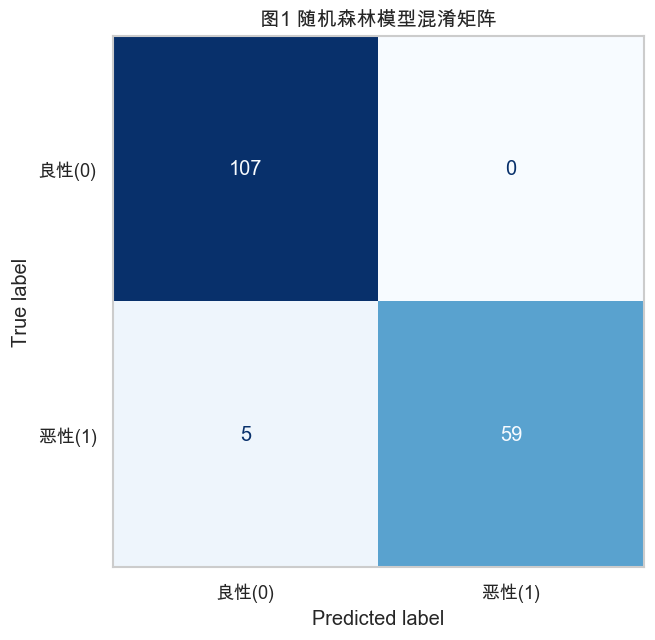

```
混淆矩阵图已保存至：/Users/heminghuang/Desktop/econ/2026-2027-1-量化投资/量化/TASK5/figure1_confusion_matrix.png
```

```python
# 图1：绘制 AUC 最高模型的混淆矩阵。
best_model_name = metrics_df.iloc[0]["模型"]
best_y_pred = prediction_results[best_model_name]["y_pred"]

fig, ax = plt.subplots(figsize=(6.5, 5.5), dpi=120)
ConfusionMatrixDisplay.from_predictions(
    y_test,
    best_y_pred,
    labels=[0, 1],
    display_labels=["良性(0)", "恶性(1)"],
    cmap="Blues",
    colorbar=False,
    ax=ax,
)
ax.set_title(f"图1 {best_model_name}模型混淆矩阵")
ax.grid(False)

confusion_figure_path = task5_dir / "figure1_confusion_matrix.png"
fig.tight_layout()
fig.savefig(confusion_figure_path, dpi=300, bbox_inches="tight")
plt.show()

print(f"混淆矩阵图已保存至：{confusion_figure_path}")
```

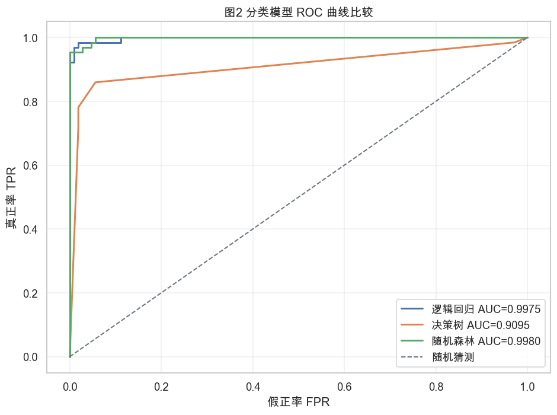

```
ROC 曲线图已保存至：/Users/heminghuang/Desktop/econ/2026-2027-1-量化投资/量化/TASK5/figure2_roc_curves.png
```

```python
# 图2：绘制三个模型的 ROC 曲线并标注 AUC。
fig, ax = plt.subplots(figsize=(8, 6), dpi=120)

for model_name, result in prediction_results.items():
    auc_value = metrics_df.loc[metrics_df["模型"] == model_name, "AUC"].iloc[0]
    ax.plot(result["fpr"], result["tpr"], linewidth=1.8, label=f"{model_name} AUC={auc_value:.4f}")

ax.plot([0, 1], [0, 1], color="#6b7280", linestyle="--", linewidth=1.2, label="随机猜测")
ax.set_title("图2 分类模型 ROC 曲线比较")
ax.set_xlabel("假正率 FPR")
ax.set_ylabel("真正率 TPR")
ax.legend(loc="lower right")
ax.grid(alpha=0.3)

roc_figure_path = task5_dir / "figure2_roc_curves.png"
fig.tight_layout()
fig.savefig(roc_figure_path, dpi=300, bbox_inches="tight")
plt.show()

print(f"ROC 曲线图已保存至：{roc_figure_path}")
```

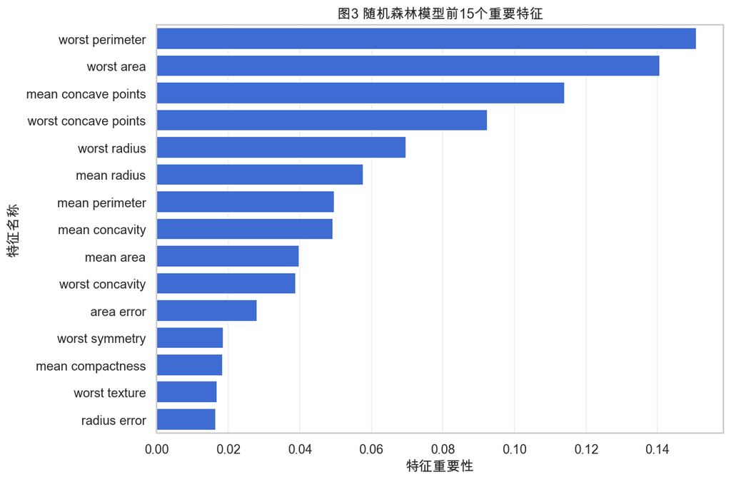

```
特征重要性表已保存至：/Users/heminghuang/Desktop/econ/2026-2027-1-量化投资/量化/TASK5/random_forest_feature_importance.csv
特征重要性图已保存至：/Users/heminghuang/Desktop/econ/2026-2027-1-量化投资/量化/TASK5/figure3_feature_importance.png
```

|  | 特征 | 重要性 |
| --- | --- | --- |
| 0 | worst perimeter | 0.150839 |
| 1 | worst area | 0.140615 |
| 2 | mean concave points | 0.114055 |
| 3 | worst concave points | 0.092458 |
| 4 | worst radius | 0.069785 |
| 5 | mean radius | 0.057723 |
| 6 | mean perimeter | 0.049740 |
| 7 | mean concavity | 0.049342 |
| 8 | mean area | 0.039759 |
| 9 | worst concavity | 0.038842 |
| 10 | area error | 0.028028 |
| 11 | worst symmetry | 0.018652 |
| 12 | mean compactness | 0.018373 |
| 13 | worst texture | 0.016874 |
| 14 | radius error | 0.016553 |

```python
# 图3：随机森林特征重要性，观察模型主要依赖哪些特征。
random_forest_model = models["随机森林"]
feature_importance = pd.DataFrame({
    "特征": X.columns,
    "重要性": random_forest_model.feature_importances_,
}).sort_values("重要性", ascending=False).reset_index(drop=True)

top_features = feature_importance.head(15)
feature_importance_path = task5_dir / "random_forest_feature_importance.csv"
feature_importance.to_csv(feature_importance_path, index=False, encoding="utf-8-sig")

fig, ax = plt.subplots(figsize=(9, 6), dpi=120)
sns.barplot(data=top_features, x="重要性", y="特征", color="#2563eb", ax=ax)
ax.set_title("图3 随机森林模型前15个重要特征")
ax.set_xlabel("特征重要性")
ax.set_ylabel("特征名称")
ax.grid(axis="x", alpha=0.3)

importance_figure_path = task5_dir / "figure3_feature_importance.png"
fig.tight_layout()
fig.savefig(importance_figure_path, dpi=300, bbox_inches="tight")
plt.show()

print(f"特征重要性表已保存至：{feature_importance_path}")
print(f"特征重要性图已保存至：{importance_figure_path}")
display(top_features)
```

```python
# 自动生成可写入报告的图表解读。
best_row = metrics_df.iloc[0]
worst_row = metrics_df.iloc[-1]
best_model_name = best_row["模型"]
best_confusion = prediction_results[best_model_name]["confusion_matrix"]
tn, fp, fn, tp = best_confusion.ravel()

interpretation = f"""
图1展示了测试集中 AUC 最高的 {best_model_name} 模型的混淆矩阵。该模型在测试集中正确识别恶性样本 {tp} 个，正确识别良性样本 {tn} 个；同时将 {fp} 个良性样本误判为恶性，将 {fn} 个恶性样本误判为良性。混淆矩阵可以帮助观察模型错误类型，尤其是在诊断或交易风控场景中，假负例和假正例的成本可能不同。

图2展示了逻辑回归、决策树和随机森林三个模型的 ROC 曲线。AUC 最高的模型是 {best_model_name}，AUC 为 {best_row['AUC']:.4f}；AUC 最低的模型是 {worst_row['模型']}，AUC 为 {worst_row['AUC']:.4f}。整体来看，ROC 曲线越靠近左上角，说明模型越能在较低误判率下识别更多正类样本。

图3展示了随机森林模型的前 15 个重要特征。排名靠前的特征说明它们在随机森林分类判断中贡献较大。在金融量化场景中，类似的特征重要性分析可以帮助研究哪些财务指标、技术指标或行情变量对预测未来收益方向更有解释力。

本次实验说明，分类模型可以通过训练集学习特征与类别之间的关系，再在测试集上检验泛化能力。AUC 和 ROC 适合评价二分类模型的区分能力，但在真实量化交易中，还需要进一步结合交易成本、收益回测、最大回撤和风险控制，不能只凭分类指标直接判断策略好坏。
"""

print(interpretation)
```

```
图1展示了测试集中 AUC 最高的 随机森林 模型的混淆矩阵。该模型在测试集中正确识别恶性样本 59 个，正确识别良性样本 107 个；同时将 0 个良性样本误判为恶性，将 5 个恶性样本误判为良性。混淆矩阵可以帮助观察模型错误类型，尤其是在诊断或交易风控场景中，假负例和假正例的成本可能不同。

图2展示了逻辑回归、决策树和随机森林三个模型的 ROC 曲线。AUC 最高的模型是 随机森林，AUC 为 0.9980；AUC 最低的模型是 决策树，AUC 为 0.9095。整体来看，ROC 曲线越靠近左上角，说明模型越能在较低误判率下识别更多正类样本。

图3展示了随机森林模型的前 15 个重要特征。排名靠前的特征说明它们在随机森林分类判断中贡献较大。在金融量化场景中，类似的特征重要性分析可以帮助研究哪些财务指标、技术指标或行情变量对预测未来收益方向更有解释力。

本次实验说明，分类模型可以通过训练集学习特征与类别之间的关系，再在测试集上检验泛化能力。AUC 和 ROC 适合评价二分类模型的区分能力，但在真实量化交易中，还需要进一步结合交易成本、收益回测、最大回撤和风险控制，不能只凭分类指标直接判断策略好坏。
```

## 四、报告写作建议

整理 PDF 时，可以按照以下结构组织：

1. 分类算法介绍：解释逻辑回归、决策树和随机森林。
2. 模型评价指标：解释混淆矩阵、ROC 曲线和 AUC。
3. 数据来源说明：说明本作业使用 scikit-learn 内置乳腺癌二分类数据集，并说明标签设置为 `1=恶性，0=良性`。
4. 模型训练过程：说明训练集/测试集划分比例为 70%/30%。
5. 模型评估结果：放入模型指标表、图1混淆矩阵和图2 ROC 曲线，并写简短解读。
6. 扩展解释：可以放入图3随机森林特征重要性，说明机器学习模型如何帮助理解关键变量。
7. 量化交易联系：说明分类模型可迁移到“预测未来收益方向”“识别风险状态”“筛选交易信号”等金融场景。

## 五、提交前检查

1. 在 `TASK5` 文件夹下提交 PDF 文档。
2. PDF 文件命名为“姓名+TASK5”。
3. 正文格式设置为宋体、五号字、1.5 倍行距、段前段后 0、文字两端对齐。
4. 所有图表都需要有编号和标题，例如“图2 分类模型 ROC 曲线比较”。
5. 每张图后面都需要写简短解读。
6. 本 notebook 默认使用 scikit-learn 内置数据集，不需要填写 Tushare Token。

## 参考资料

1. scikit-learn 官方文档：`load_breast_cancer` 数据集。https://scikit-learn.org/stable/modules/generated/sklearn.datasets.load_breast_cancer.html
2. scikit-learn 官方文档：`RandomForestClassifier`。https://scikit-learn.org/stable/modules/generated/sklearn.ensemble.RandomForestClassifier.html
3. scikit-learn 官方文档：`roc_auc_score`。https://scikit-learn.org/stable/modules/generated/sklearn.metrics.roc_auc_score.html
4. scikit-learn 官方文档：`roc_curve`。https://scikit-learn.org/stable/modules/generated/sklearn.metrics.roc_curve.html
5. scikit-learn 官方文档：`confusion_matrix`。https://scikit-learn.org/stable/modules/generated/sklearn.metrics.confusion_matrix.html